# Estimasi Informasi Nilai Zat Gizi Pangan untuk UMK

Zaky Nur Kusmantoro

2024-05-11

## Latar Belakang

Pencantuman label ING harus dibuktikan dengan hasil analisis zat gizi dari laboratorium terkait (pemerintah atau lainnya yang sudah terakreditasi). Kemudian pada kelompok UMK (Usaha Mikro dan Kecil ) sering mengalami kesulitan dan keterbatasan dalam pemenuhan analisis laboratorium. Badan POM melalui **PerBPOM No. 16 Tahun 2020** dan **Keputusan Kepala BPOM No. HK.02.02.1.2.12.21.494 Tahun 2021** mengatur tentang deskripsi, nilai kandungan gizi per 100 gram, dan takaran saji pangan olahan pada 163 jenis pangan yang diproduksi oleh UMK dan wajib mencantumkan ING. Pada tahun 2023, terjadi penambahan 50 jenis pangan yang wajib mencantumkan ING.

Dalam hal ini, UMK dituntut untuk patuh dalam regulasi, akan tetapi salah satu langkah wajib yang sulit dipenuhi adalah keterbatasan dalam analisis laboratorium. Badan POM melakukan pengkajian dengan mengestimasi kandungan nilai gizi yang diperlukan dalam setiap jenis pangan agar dapat digunakan oleh UMK sebagai acuan yang digunakan pada produknya

## Penentuan Jenis Pangan

hingga terpilih 50 jenis pangan sebagai berikut

```r
#List Jenis Pangan
data_jp %>% print(n = Inf)
```

```
## # A tibble: 50 × 2
##    `JENIS PANGAN`                                                                                    `KODE JP`
##    <chr>                                                                                             <chr>
##  1 Biskuit Gem Rose/Kue kancing/Kue monas                                                            JP5
##  2 Brownies crispy                                                                                   JP8
##  3 Campuran Bubuk Susu Kambing Rasa                                                                  JP9
##  4 Dendeng ayam                                                                                      JP12
##  5 Egg roll                                                                                          JP15
##  6 Es lilin                                                                                          JP16
##  7 Es susu                                                                                           JP17
##  8 Gula aren                                                                                         JP18
##  9 Jagung berondong/popcorn                                                                          JP20
## 10 Kacang tanah panggang                                                                             JP24
## 11 Kastengel                                                                                         JP25
## 12 Kecap kedelai asin                                                                                JP26
```

[output cut: 38 more lines]

## Estimasi Kandungan Gizi

Kandungan Gizi diperoleh berdasarkan data pengujian produk pangan olahan UMK hasil sampling da data kandungan gizi pangan olahan terdaftar MD pada periode Januari 2020-Juni 2023 (sumber data: RPO). Kandungan gizi tersebut mencakup 7 komponen yaitu **Energi total, Protein, Lemak total, Lemak jenuh, Karbohidrat total, Gula total, dan Garam (Natrium)**. Jenis gizi yang wajib dicantumkan sesuai dengan Pasal 5 Peraturan BPOM Nomor 26 Tahun 2021 tentang Informasi Nilai Gizi pada Label Pangan Olahan

## Perhitungan Estimasi Kandungan Gizi

### Alur Analisis

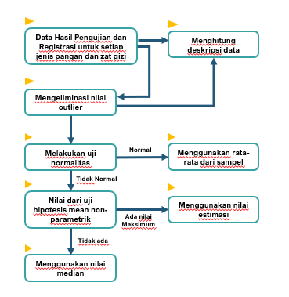

### Identifikasi Outlier

Outlier merupakan data pencilan yang jauh berada di sekumpulan kelompok data pada umumnya. Dalam mengestimasi, umumnya dilakukan perhitungan rata-rata. Dan, rata-rata sangat terpengaruh dengan nilai outlier tersebut, sehingga perlu diidentifikasi nilai mana saja yang termasuk outlier dan perlu untuk tidak disertakan pada analisis selanjutnya. Metode yang paling mudah adalah dengan menggunakan boxplot. Pada boxplot, nantinya akan terlihat titik-titik yang menandakan outlier. Selain itu, dengan boxplot bisa melihat secara visual persebaran datanya

```
### rumus boxplot ####
loop_bxp <- function(x){ # x=>
  x.ind <- list()
  x.ind[[1]] <- x

  out.ind <- list()
  out.ind[[1]] <- out.ind[[1]] <- boxplot(x, plot = FALSE)$out

  i <- 2 #mulai indeks 2
  while(i < 100){
    x.ind[[i]] = unlist(x.ind[i-1])[!x.ind[[i-1]] %in% out.ind[[i-1]]]
    out.ind[[i]] = boxplot(unlist(x.ind[i]),plot = FALSE)$out
    if(length(out.ind[[i]]) == 0){
      #print()
      return(unlist(x.ind[[i]]))
      break
    } else
      i=i+1
  }
}
```

#### Energi Total

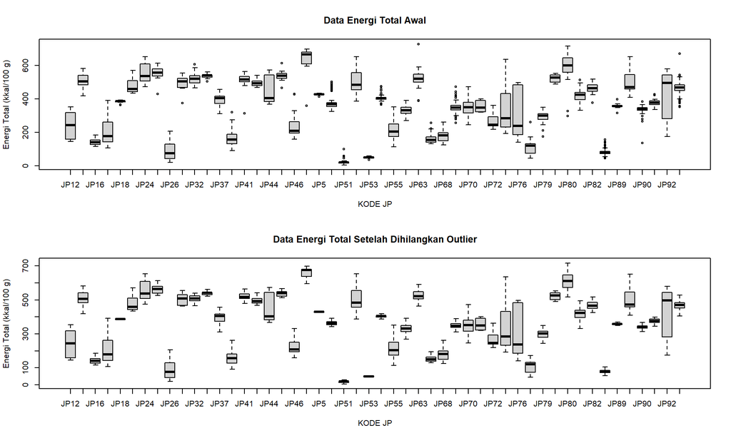

Berikut untuk nilai ukuran pusat dan sebaran dari Energi Total untuk setiap jenis pangan yang sudah dilakukan penanganan outlier

| KODE JP | JENIS PANGAN | N | Min | Rata-rata | Median | Maks |
| --- | --- | --- | --- | --- | --- | --- |
| JP12 | Dendeng ayam | 8 | 146 | 242.61 | 244 | 353 |
| JP15 | Egg roll | 33 | 419.63 | 507.01 | 505.47 | 583.14 |
| JP16 | Es lilin | 10 | 116.87 | 144.03 | 141.02 | 185.27 |
| JP17 | Es susu | 216 | 107.94 | 203.61 | 178.26 | 392.44 |
| JP18 | Gula aren | 8 | 385.64 | 388.04 | 386.5 | 392.78 |
| JP20 | Jagung berondong/popcorn | 23 | 434.43 | 474.66 | 458.96 | 571 |
| JP24 | Kacang tanah panggang | 40 | 474.22 | 551.17 | 537.08 | 654 |
| JP25 | Kastengel | 13 | 526.26 | 563.43 | 565 | 613.81 |
| JP26 | Kecap kedelai asin | 47 | 21.2 | 89.68 | 76.08 | 206.16 |
| JP30 | Kerupuk bawang matang | 14 | 464.37 | 502.96 | 508.12 | 556.01 |

[output cut: 40 more lines]

#### Protein

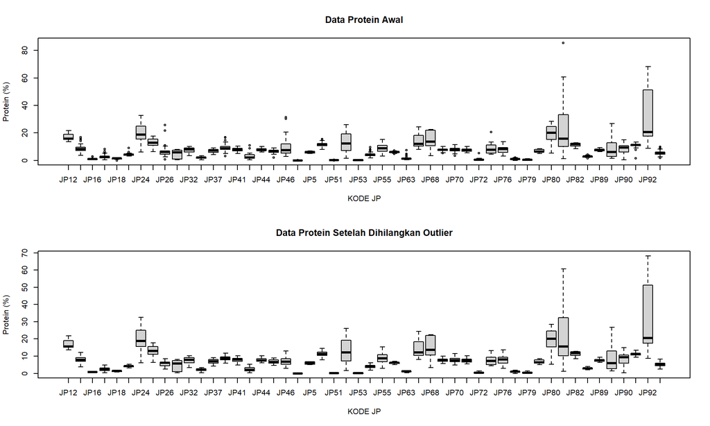

Berikut untuk nilai ukuran pusat dan sebaran dari Protein untuk setiap jenis pangan yang sudah dilakukan penanganan outlier

| KODE JP | JENIS PANGAN | N | Min | Rata-rata | Median | Maks |
| --- | --- | --- | --- | --- | --- | --- |
| JP12 | Dendeng ayam | 8 | 13.6 | 16.86 | 15.66 | 21.7 |
| JP15 | Egg roll | 28 | 3.75 | 7.83 | 7.8 | 12.11 |
| JP16 | Es lilin | 7 | 0.59 | 0.75 | 0.71 | 0.91 |
| JP17 | Es susu | 211 | 0.34 | 2.43 | 2.37 | 4.83 |
| JP18 | Gula aren | 10 | 0.81 | 1.36 | 1.44 | 1.87 |
| JP20 | Jagung berondong/popcorn | 21 | 3.17 | 4.09 | 4.12 | 5.17 |
| JP24 | Kacang tanah panggang | 40 | 6.11 | 19.9 | 18.84 | 32.6 |
| JP25 | Kastengel | 14 | 6.36 | 12.89 | 12.9 | 17.7 |
| JP26 | Kecap kedelai asin | 40 | 2.46 | 5.71 | 6.08 | 8.45 |
| JP30 | Kerupuk bawang matang | 15 | 0.31 | 4.53 | 5.79 | 8.01 |

[output cut: 40 more lines]

#### Lemak Total

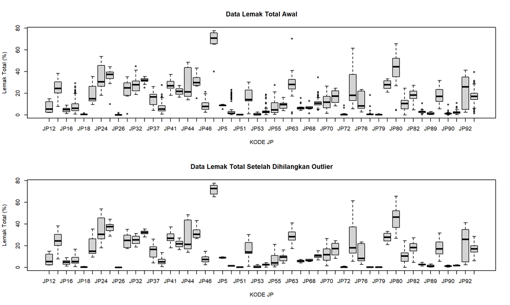

Berikut untuk nilai ukuran pusat dan sebaran dari Lemak Total untuk setiap jenis pangan yang sudah dilakukan penanganan outlier

| KODE JP | JENIS PANGAN | N | Min | Rata-rata | Median | Maks |
| --- | --- | --- | --- | --- | --- | --- |
| JP12 | Dendeng ayam | 8 | 2.12 | 7.04 | 5.2 | 14.8 |
| JP15 | Egg roll | 33 | 7.59 | 24.3 | 24.23 | 38.3 |
| JP16 | Es lilin | 10 | 1.03 | 4.78 | 4.88 | 8.87 |
| JP17 | Es susu | 200 | 0.64 | 6.71 | 5.38 | 16.72 |
| JP18 | Gula aren | 10 | 0 | 0.29 | 0.26 | 0.82 |
| JP20 | Jagung berondong/popcorn | 23 | 9.44 | 18.57 | 14.88 | 35.4 |
| JP24 | Kacang tanah panggang | 40 | 18.02 | 33.91 | 30.52 | 53.91 |
| JP25 | Kastengel | 13 | 28.78 | 37.11 | 37.6 | 44.22 |
| JP26 | Kecap kedelai asin | 41 | 0 | 0.01 | 0 | 0.05 |
| JP30 | Kerupuk bawang matang | 14 | 17.32 | 24.94 | 24.8 | 34.97 |

[output cut: 40 more lines]

#### Lemak Jenuh

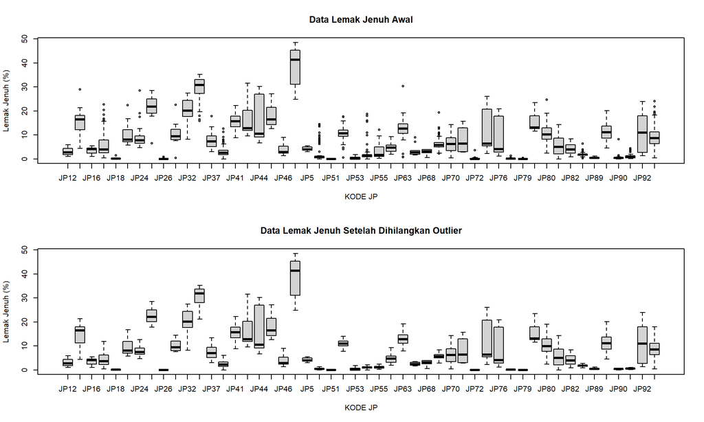

Berikut untuk nilai ukuran pusat dan sebaran dari Lemak Jenuh untuk setiap jenis pangan yang sudah dilakukan penanganan outlier

| KODE JP | JENIS PANGAN | N | Min | Rata-rata | Median | Maks |
| --- | --- | --- | --- | --- | --- | --- |
| JP12 | Dendeng ayam | 8 | 1.07 | 3.07 | 2.62 | 5.91 |
| JP15 | Egg roll | 32 | 4.42 | 14.84 | 16.49 | 21.4 |
| JP16 | Es lilin | 10 | 0.93 | 3.61 | 4.09 | 5.44 |
| JP17 | Es susu | 190 | 0.42 | 4.46 | 3.62 | 11.92 |
| JP18 | Gula aren | 10 | 0 | 0.13 | 0.13 | 0.37 |
| JP20 | Jagung berondong/popcorn | 22 | 5.75 | 9.54 | 7.96 | 16.74 |
| JP24 | Kacang tanah panggang | 37 | 4.65 | 7.79 | 7.4 | 12.58 |
| JP25 | Kastengel | 13 | 17.8 | 22.36 | 22.14 | 28.57 |
| JP26 | Kecap kedelai asin | 34 | 0 | 0 | 0 | 0 |
| JP30 | Kerupuk bawang matang | 13 | 7.6 | 10.16 | 9.38 | 14.4 |

[output cut: 40 more lines]

#### Karbohidrat Total

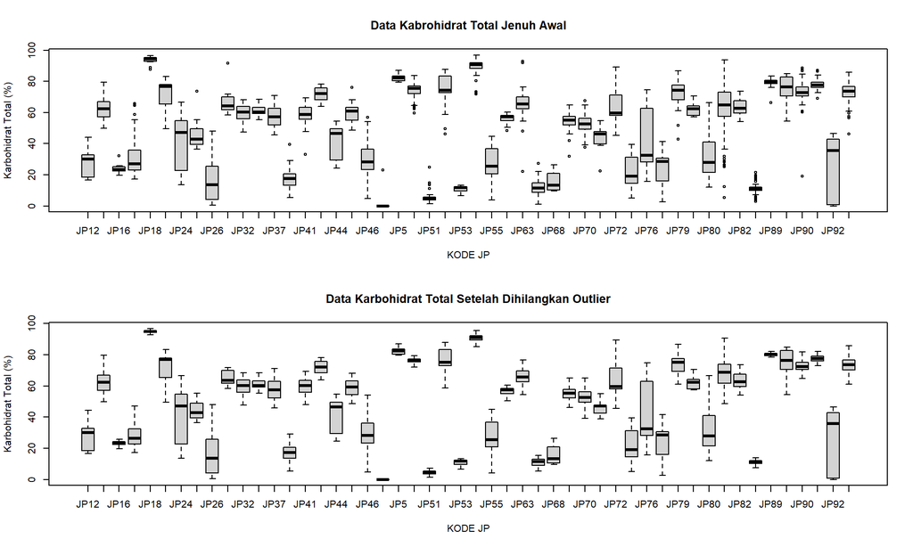

Berikut untuk nilai ukuran pusat dan sebaran dari Karbohidrat Total untuk setiap jenis pangan yang sudah dilakukan penanganan outlier

| KODE JP | JENIS PANGAN | N | Min | Rata-rata | Median | Maks |
| --- | --- | --- | --- | --- | --- | --- |
| JP12 | Dendeng ayam | 8 | 16.56 | 27.94 | 30.1 | 44.2 |
| JP15 | Egg roll | 33 | 49.77 | 63.04 | 62.3 | 79.62 |
| JP16 | Es lilin | 9 | 19.76 | 23.13 | 23.39 | 25.68 |
| JP17 | Es susu | 199 | 17.35 | 28.64 | 26.22 | 47.11 |
| JP18 | Gula aren | 9 | 92.76 | 94.78 | 94.91 | 96.7 |
| JP20 | Jagung berondong/popcorn | 23 | 49.58 | 72.47 | 76.89 | 83.2 |
| JP24 | Kacang tanah panggang | 40 | 13.6 | 41.59 | 47.12 | 66.66 |
| JP25 | Kastengel | 13 | 36.56 | 44.38 | 42.74 | 55.4 |
| JP26 | Kecap kedelai asin | 47 | 0.5 | 15.66 | 13.56 | 47.99 |
| JP30 | Kerupuk bawang matang | 14 | 58.5 | 64.79 | 63.6 | 71.86 |

[output cut: 40 more lines]

#### Gula Total

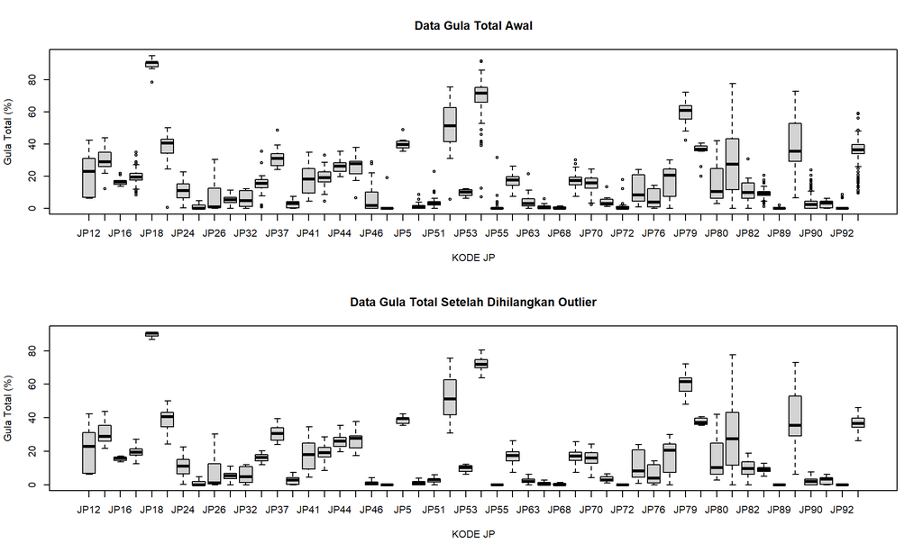

Berikut untuk nilai ukuran pusat dan sebaran dari Gula Total untuk setiap jenis pangan yang sudah dilakukan penanganan outlier

| KODE JP | JENIS PANGAN | N | Min | Rata-rata | Median | Maks |
| --- | --- | --- | --- | --- | --- | --- |
| JP12 | Dendeng ayam | 8 | 6.13 | 21.14 | 22.74 | 42.3 |
| JP15 | Egg roll | 32 | 21.69 | 30.63 | 28.89 | 43.72 |
| JP16 | Es lilin | 8 | 13.52 | 15.55 | 15.88 | 17.2 |
| JP17 | Es susu | 204 | 12.36 | 19.74 | 19.42 | 26.97 |
| JP18 | Gula aren | 9 | 86.7 | 89.5 | 90.6 | 91.02 |
| JP20 | Jagung berondong/popcorn | 22 | 24.31 | 39.26 | 40.73 | 50.17 |
| JP24 | Kacang tanah panggang | 40 | 0.28 | 11.13 | 11.05 | 22.57 |
| JP25 | Kastengel | 14 | 0 | 1.03 | 0 | 4.62 |
| JP26 | Kecap kedelai asin | 47 | 0 | 6.34 | 0.9 | 30.28 |
| JP30 | Kerupuk bawang matang | 15 | 0 | 5.32 | 5.22 | 11.13 |

[output cut: 40 more lines]

#### Natrium

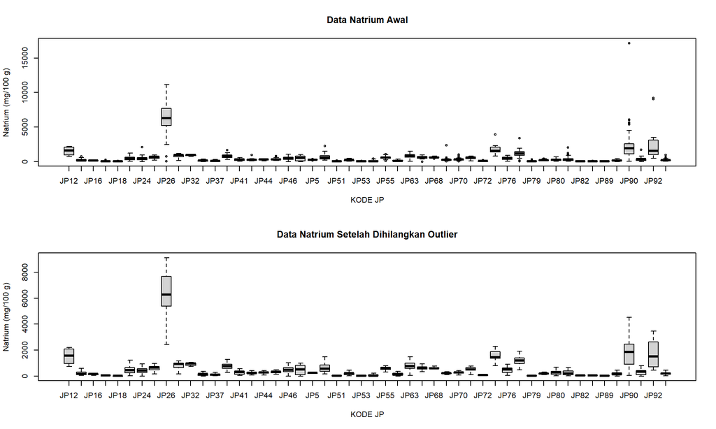

| KODE JP | JENIS PANGAN | N | Min | Rata-rata | Median | Maks |
| --- | --- | --- | --- | --- | --- | --- |
| JP12 | Dendeng ayam | 8 | 736 | 1523.61 | 1574.95 | 2210 |
| JP15 | Egg roll | 32 | 44.6 | 210.24 | 154.82 | 585 |
| JP16 | Es lilin | 10 | 53.58 | 136.65 | 148.85 | 227.9 |
| JP17 | Es susu | 186 | 0 | 44.93 | 41.3 | 97.27 |
| JP18 | Gula aren | 10 | 0 | 12.39 | 8.72 | 45.03 |
| JP20 | Jagung berondong/popcorn | 23 | 8.84 | 451.39 | 460.13 | 1233.32 |
| JP24 | Kacang tanah panggang | 39 | 0 | 409.46 | 423.85 | 947.5 |
| JP25 | Kastengel | 14 | 167.99 | 601.85 | 658.86 | 970 |
| JP26 | Kecap kedelai asin | 44 | 2437.87 | 6488.09 | 6282.23 | 9126.63 |
| JP30 | Kerupuk bawang matang | 15 | 161.76 | 810.56 | 927 | 1174.69 |

[output cut: 40 more lines]

### Uji Normalitas (Parametrik)

Uji Normalitas adalah suatu statistik inferensi yang digunakan untuk mengambil kesimpulan apakah data tersebut berdistribusi normal atau tidak pada tingkat signifikansi tertentu. Pada perhitungan ini, digunakan tingkat signifikansi sebesar 5%.

Pada uji normalitas ini menggunakan metode **Jarque-Berra** adalah salah satu uji normalitas jenis **goodness of fit test** yang mana mengukur apakah **skewness** dan **kurtosis** dari sampel sesuai dengan distribusi normal. Uji ini didasarkan pada kenyataan bahwa nilai skewness dan kurtosis dari distribusi normal sama dengan nol.

Suatu data dikatakan mengikuti distribusi normal jika nilai p-value ≥ 0,05 (karena tingkat signifikansi adalah 5%)

#### Energi Total

```r
left_join(df_energi_norm,data_jp,by = "KODE JP") %>% filter(`Normal?` %in% "Tidak") %>%
  select(`KODE JP`,`JENIS PANGAN`,`P-Value`,`Normal?`)
```

```
## # A tibble: 2 × 4
##   `KODE JP` `JENIS PANGAN`                   `P-Value` `Normal?`
##   <chr>     <chr>                                <dbl> <chr>
## 1 JP17      Es susu                             0      Tidak
## 2 JP9       Campuran Bubuk Susu Kambing Rasa    0.0015 Tidak
```

#### Protein

```r
left_join(df_protein_norm,data_jp,by = "KODE JP") %>% filter(`Normal?` %in% "Tidak") %>% select(`KODE JP`,`JENIS PANGAN`,`P-Value`,`Normal?`)
```

```
## # A tibble: 3 × 4
##   `KODE JP` `JENIS PANGAN`                   `P-Value` `Normal?`
##   <chr>     <chr>                                <dbl> <chr>
## 1 JP81      Serbuk minuman kedelai              0.0127 Tidak
## 2 JP9       Campuran Bubuk Susu Kambing Rasa    0.0007 Tidak
## 3 JP90      Tepung bumbu                        0.0074 Tidak
```

#### Lemak Total

```r
left_join(df_lemak_total_norm,data_jp,by = "KODE JP") %>% filter(`Normal?` %in% "Tidak") %>% select(`KODE JP`,`JENIS PANGAN`,`P-Value`,`Normal?`)
```

```
## # A tibble: 4 × 4
##   `KODE JP` `JENIS PANGAN`                   `P-Value` `Normal?`
##   <chr>     <chr>                                <dbl> <chr>
## 1 JP17      Es susu                             0      Tidak
## 2 JP26      Kecap kedelai asin                  0      Tidak
## 3 JP51      Minuman jeli                        0.042  Tidak
## 4 JP9       Campuran Bubuk Susu Kambing Rasa    0.0376 Tidak
```

#### Lemak Jenuh

```
## # A tibble: 4 × 4
##   `KODE JP` `JENIS PANGAN`           `P-Value` `Normal?`
##   <chr>     <chr>                        <dbl> <chr>
## 1 JP17      Es susu                     0      Tidak
## 2 JP36      Krimer minuman              0.0146 Tidak
## 3 JP72      Sagu mutiara                0.026  Tidak
## 4 JP93      Wafer Roll / Wafer Stick    0.0158 Tidak
```

#### Karbohidrat Total

```
## # A tibble: 3 × 4
##   `KODE JP` `JENIS PANGAN`                   `P-Value` `Normal?`
##   <chr>     <chr>                                <dbl> <chr>
## 1 JP17      Es susu                             0      Tidak
## 2 JP26      Kecap kedelai asin                  0.0471 Tidak
## 3 JP9       Campuran Bubuk Susu Kambing Rasa    0.0069 Tidak
```

#### Gula Total

```
## # A tibble: 4 × 4
##   `KODE JP` `JENIS PANGAN`     `P-Value` `Normal?`
##   <chr>     <chr>                  <dbl> <chr>
## 1 JP26      Kecap kedelai asin    0.0037 Tidak
## 2 JP50      Mi kering             0.0008 Tidak
## 3 JP78      Saus tomat            0.0174 Tidak
## 4 JP90      Tepung bumbu          0.0157 Tidak
```

#### Natrium

```
## # A tibble: 5 × 4
##   `KODE JP` `JENIS PANGAN`                   `P-Value` `Normal?`
##   <chr>     <chr>                                <dbl> <chr>
## 1 JP17      Es susu                             0.0074 Tidak
## 2 JP50      Mi kering                           0.0382 Tidak
## 3 JP54      Minuman serbuk kopi gula            0.0055 Tidak
## 4 JP9       Campuran Bubuk Susu Kambing Rasa    0.0159 Tidak
## 5 JP93      Wafer Roll / Wafer Stick            0      Tidak
```

Jika berdistribusi normal, maka rata-rata sampel dapat digunakan sebagai estimasi nilai zat gizi pada setiap jenis pangannya. Kemudian, untuk yang tidak berdistribusi normal bisa ditinjau kembali penentuan estimasi nilai zat gizinya pada setiap jenis pangan

```
nonpar <- function(df_test){
  df_test <- unique(df_test)
  if(length(which(is.na(df_test))) > 0){
    df_test <- df_test[!is.na(df_test)]
  } else
    df_test
  #===processing data===
  xx <- seq(min(df_test),max(df_test),length=2e3)  #iteasi hingga 2000
  n_pvalue <- NULL
  for(i in 1:length(xx)){
    n_pvalue[i] <- (wilcox.test(df_test,mu = xx[i], exact = FALSE))$p.value
  }
  init_mean <- xx[which(n_pvalue %in% max(n_pvalue))]
  if(length(init_mean) > 1){
    return(median(df_test))
  } else
  return(init_mean)
}
```

Berikut adalah *summarise* nilai estimasi Nilai Zat Gizi Pangan untuk UMK

| KODE JP | JENIS PANGAN | Energi Total | Protein | Lemak Total | Lemak Jenuh | Karbohidrat | Gula Total | Garam |
| --- | --- | --- | --- | --- | --- | --- | --- | --- |
| JP12 | Dendeng ayam | 242.61 | 16.86 | 7.04 | 3.07 | 27.94 | 21.14 | 1523.61 |
| JP15 | Egg roll | 507.01 | 7.83 | 24.3 | 14.84 | 63.04 | 30.63 | 210.24 |
| JP16 | Es lilin | 144.03 | 0.75 | 4.78 | 3.61 | 23.13 | 15.55 | 136.65 |
| JP17 | Es susu | 200.16 | 2.43 | 6.34 | 4.32 | 27.65 | 19.74 | 43.7 |
| JP18 | Gula aren | 388.04 | 1.36 | 0.29 | 0.13 | 94.78 | 89.5 | 12.39 |
| JP20 | Jagung berondong/popcorn | 474.66 | 4.09 | 18.57 | 9.54 | 72.47 | 39.26 | 451.39 |
| JP24 | Kacang tanah panggang | 551.17 | 19.9 | 33.91 | 7.79 | 41.59 | 11.13 | 409.46 |
| JP25 | Kastengel | 563.43 | 12.89 | 37.11 | 22.36 | 44.38 | 1.03 | 601.85 |
| JP26 | Kecap kedelai asin | 89.68 | 5.71 | 0.03 | 0 | 15.28 | 7.08 | 6488.09 |
| JP30 | Kerupuk bawang matang | 502.96 | 4.53 | 24.94 | 10.16 | 64.79 | 5.32 | 810.56 |

[output cut: 40 more lines]